# Multiple Choice

Econometrics - Chapter 26

Mateus Lee Yu

Wesley Cabral Alves

2026-07-01

# Introdução

## Resposta Multinomial

- Definição (Resposta Multinomial): O par $(Y, X)$ é uma resposta multinomial quando $X \in \mathbb{R}^{k}$ e $Y$ é multinomial, ou seja, $Y$ pertence a um conjunto finito de alternativas ($Y \in \{1, \dots, J \}$).
- Exemplo: $Y$ o estado civil (“casado”, “divorciado”, “separado”, “nunca casado”) e $X$ a idade de uma pessoa.
- Definição (Probabilidade de Resposta): É a distribuição condicional de $Y$ dado $X$,
  $$P_{j}(x) = \mathbb{P}[Y=j | X=x].$$
- A resposta multinomial motiva a utilização do Modelo de Utilidade Latente.

## Modelo de Utilidade Latente

- No Modelo de Utilidade Latente, o indivíduo assume a alternativa com maior utilidade, ou seja, $Y=j$ se $U_{j}^{*} > U_{l}^{*}$ para todo $l \neq j$.
- A utilidade da $j$-ésima alternativa é
  $$U_{j}^{*} = X^{'} \beta_{j} + \epsilon_{j},$$
  onde $\beta_{j}$ é o coeficiente e $\epsilon_{j}$ o erro da alternativa $j$.
- Observação: Os coeficientes $\beta_{j}$ não são separadamente identificados. Portanto fixamos $\beta_{j} = 0$, para que a diferença dos coeficientes $\beta_{j} - \beta_{l}$ seja identificado.
- Os dois modelos de respostas multinomiais clássicos são os modelos Logit e Probit.

# Modelo Logit

- Definição 26.1: A distribuição de Valor Extremo Tipo I é dado por
  $$F(\epsilon) = \exp(-\exp(-\epsilon)).$$
- Definição 26.2: A distribuição conjunta Generalized Extreme Values (GEV) é dado por
  $$F(\epsilon_{1}, \dots, \epsilon_{J}) = \exp \left( - \left[ \sum_{j=1}^{J} \exp \left( \frac{\epsilon_{j}}{\tau} \right) \right] \right),$$
  onde $0 < \tau \leq 1$.
- Observação: Quando $\tau = 1$, a distribuição GEV coincide com a distribuição de $(\epsilon_{1}, \dots, \epsilon_{J})$, onde $\epsilon_{1}, \dots, \epsilon_{J}$ são i.i.d. com distribuição de Valor Extremo Tipo I.

## Modelo Simples Logit

- Teorema 26.1: Assuma que a utilidade da alternativa $j$ é dado por $U_{j}^{*} = X^{'} \beta_{j} + \epsilon_{j}$, e o vetor de erros $(\epsilon_{1}, \dots, \epsilon_{J})$ com distribuição GEV. Então, as probabilidades de resposta são
  $$P_{j}(x) = \frac{\exp(x^{'} \beta_{j} / \tau)}{\sum_{l=1}^{J} \exp(x^{'} \beta_{l} / \tau)}.$$
- Observação: Por conveniência algébrica, utilizamos $\tau = 1$.
- Definição: O Modelo Simples Logit é dado por
  $$P_{j}(x) = \frac{\exp(x^{'} \beta_{j})}{\sum_{l=1}^{J} \exp(x^{'} \beta_{l})}.$$

## Estimação

- Para cada $i$-ésima observação $\{ Y_{i}, X_{i} \}$ e coeficientes $\beta = (\beta_{1}, \dots, \beta_{J})$, temos que a função de distribuição
  $$\pi(Y_{i} | X_{i}, \beta) = \prod_{j=1}^{J} P_{j}(X_{i} | \beta)^{\mathbf{1}\{ Y_{i} = j \}}.$$
- A função de log-verossimilhança é
  $$l_{n}(\beta) = \sum_{i=1}^{n} \sum_{j=1}^{J} \mathbf{1}\{ Y_{i} = j \} \log P_{j}(X_{i} | \beta).$$
- O estimador de máxima verossimilhança $\widehat{\beta} = \underset{\beta}{\operatorname{argmax}} l_{n}(\beta)$ não tem solução fechada, portanto deve ser encontrada numericamente.
- Observação: A função de verossimilhança é côncava, então a maximização é direta.

## Interpretação

- O efeito marginal da alternativa $j$ é
  $$\delta_{j}(x) = \frac{\partial}{\partial x} P_{j}(x) = P_{j}(x) \left( \beta_{j} - \sum_{l=1}^{J} \beta_{l} P_{l}(x) \right),$$
  e estimador por
  $$\widehat{\delta}_{j}(x) = \widehat{P}_{j}(x) \left( \widehat{\beta}_{j} - \sum_{l=1}^{J} \widehat{\beta}_{l} \widehat{P}_{l}(x) \right).$$
- A média do efeito marginal (Average Marginal Effect) é $\operatorname{AME}_{j} = \mathbb{E}[\delta_{j}(X)]$ e estimador por
  $$\widehat{\operatorname{AME}}_{j} = \frac{1}{n} \sum_{i=1}^{n} \widehat{\delta}_{j}(X_{i}).$$

## Modelo Logit Condicional

- Exemplo: Suponha que estamos interessados no modo de transporte dos estudantes (“andando”, “bicicleta”, “ônibus”, “trem”, “carro”). Diversos fatores influenciam a escolha do modo de transporte, mas principalmente o custo, que depende do indivíduo e das alternativas.
- O Modelo Logit Condicional é dado por
  $$U_{j}^{*} = W^{'} \beta_{j} + X_{j}^{'} \gamma + \epsilon_{j}.$$
- Sob a suposição de que $\epsilon_{1}, \dots, \epsilon_{J}$ são i.i.d. com distribuição de Valor Extremo Tipo I. A partir do Teorema 26.1, as probabilidades de resposta são dadas por
  $$P_{j}(w,x) = \frac{\exp(w^{'} \beta_{j} + x_{j}^{'} \gamma)}{\sum_{l=1}^{J} \exp(w^{'} \beta_{l} + x_{l}^{'} \gamma)}.$$

## Estimação

- Para cada $i$-ésima observação $\{ Y_{i}, W_{i}, X_{i} \}$, onde $X_{i} = \{ X_{1i}, \dots, X_{Ji} \}$, a função de log-verossimilhança é
  $$l_{n}(\beta, \gamma) = \sum_{i=1}^{n} \sum_{j=1}^{J} \mathbf{1}\{ Y_{i} = j \} \log P_{j}(W_{i}, X_{i} | \beta, \gamma).$$
- Os estimadores de máxima verossimilhança $\widehat{\beta}, \widehat{\gamma} = \underset{\beta, \gamma}{\operatorname{argmax}} l_{n}(\beta, \gamma)$ não possuem solução fechada, portanto devem ser encontradas numericamente.

## Interpretação

- Os efeitos marginais é
  $$\delta_{jj}(w,x) = \frac{\partial}{\partial x_{j}} P_{j}(w,x) = \gamma P_{j}(w,x) (1 - P_{j}(w,x))$$
  e
  $$\delta_{jl}(w,x) = \frac{\partial}{\partial x_{l}} P_{j}(w,x) = -\gamma P_{j}(w,x) P_{l}(w,x) \quad \text{para $j \neq l$},$$
  e estimados substituindo por $\widehat{\gamma}$, $\widehat{P}_{j}(w,x)$ e $\widehat{P}_{l}(w,x)$.
- A média do efeito marginal é $\operatorname{AME}_{jl} = \mathbb{E}[\delta_{jl}(X)]$, e estimador pela média de $\delta_{jl}(w_{i},x_{i})$.

## Independência das Alternativas Irrelevantes

- A Independência das Alternativas Irrelevantes (Independence of Irrelevant Alternative ou IIA) é uma propriedade do modelo Logit, uma restrição sobre a razão das probabilidades de resposta,
  $$\frac{P_{j}(W,X | \beta, \gamma)}{P_{l}(W,X | \beta, \gamma)}
  = \frac{\frac{\exp(W^{'} \beta_{j} + X_{j}^{'} \gamma)}{\sum_{k=1}^{J} \exp(w^{'} \beta_{k} + x_{k}^{'} \gamma)}}{\frac{\exp(W^{'} \beta_{l} + X_{l}^{'} \gamma)}{\sum_{k=1}^{J} \exp(w^{'} \beta_{k} + x_{k}^{'} \gamma)}}
  = \frac{\exp(W^{'} \beta_{j} + X_{j}^{'} \gamma)}{\exp(W^{'} \beta_{l} + X_{l}^{'} \gamma)}.$$

## Exemplo Clássico

- Suponha que as alternativas de transporte carro ($j=1$) e ônibus vermelho ($j=2$) tem probabilidades de resposta iguais a 50%, ou seja,
  $$\frac{P_{1}(W,X | \beta, \gamma)}{P_{2}(W,X | \beta, \gamma)} = 1.$$
- Agora suponha que uma nova alternativa seja adicionado, ônibus azul ($j=3$) com as mesmas características do ônibus vermelho, então
  $$\frac{P_{2}(W,X | \beta, \gamma)}{P_{3}(W,X | \beta, \gamma)} = 1,$$
- Então, esperamos as probabilidades resposta 50% para carro, 25% para ônibus vermelho e 25% para ônibus azul.
- Portanto, como a inclusão da alternativa não deveria afetar a razão entre as probabilidades de resposta de carro e ônibus vermelho, as novas probabilidades são iguais a 33%.

## Modelo Nested Logit

- Para resolver este problema, o modelo Nested Logit divide as alternativas em grupos, onde os alternativas dentro de cada grupo são correlacionadas mas não correlacionadas entre diferentes grupos.
- O modelo denota $J$ o número de grupos, $N_j$ alternativas no grupo $j$ e “$jk$” representa a alternativa “$k$” do grupo “$j$”.
- A utilidade de $jk$-ésima alternativa é dada por
  $$U_{jk}^{*} = W^{'} \beta_{jk} + X_{jk}^{'} \gamma + \epsilon_{jk},$$
  onde os erros possuem distribuição GEV generalizada, dada por
  $$F(\epsilon_{11}, \dots, \epsilon_{JK_{j}}) = \exp \left( -\sum_{j = 1}^{J} \left[ \sum_{k = 1}^{K_{j}} \exp \left( -\frac{\epsilon_{jk}}{\tau_{j}} \right) \right]^{\tau_{j}} \right).$$
- Teorema 26.2: Assuma que a utilidade da alternativa “$jk$” seja $U_{jk}^{*} = W^{'} \beta_{jk} + X_{jk}^{'} \gamma + \epsilon_{jk} = \mu_{jk} + \epsilon_{jk}$ e os erros com a distribuição GEV generalizada. Então a probabilidade de resposta será $P_{jk} = P_{k|j}P_{j}$, onde
  $$P_{k|j} = \frac{\exp(\mu_{jk} / \tau_{j})}{\sum_{m = 1}^{K_{j}} \exp(\mu_{jm} / \tau_{j})}$$
  e
  $$P_{j} = \frac{\left( \sum_{m = 1}^{K_{j}} \exp(\mu_{jm} / \tau_{j}) \right)^{\tau_{j}}}{\sum_{l = 1}^{J} \left( \sum_{m = 1}^{K_{l}} \exp(\mu_{lm} / \tau_{l}) \right)^{\tau_{l}}}.$$

## Estimação

- A função de log-verossimilhança é
  $$l_{n}(\beta, \gamma) = \sum_{i = 1}^{n} \sum_{j = 1}^{J} \sum_{k = 1}^{K_{j}} \mathbf{1}(Y_{i} = jk) \left(\right.\log P_{k|j}(W_{i}, X_{i} | \beta, \gamma) + \log P_{j}(W_{i}, X_{i} | \beta, \gamma) \left.\right)$$
- Os estimadores de máxima verossimilhança $\widehat{\beta}, \widehat{\gamma} = \underset{\beta, \gamma}{\operatorname{argmax}} l_{n}(\beta, \gamma)$ não possuem solução fechada, portanto devem ser encontradas numericamente.

## Modelo Mixed Logit

- O modelo Mixed Logit generaliza o modelo Logit Condicional, $U_{j}^{*} = W^{'} \beta_{j} + X_{j}^{'} \gamma + \epsilon_{j}$, substituindo $\gamma$ por $\eta$,
  $$U_{j}^{*} = W^{'} \beta_{j} + X_{j}^{'} \eta + \epsilon_{j},$$
  onde $\eta$ é uma variável aleatória com distribuição $F(\eta | \alpha)$.
- As escolhas das distribuições mais comuns são: $\mathcal{N}(\gamma, D)$ (matriz de covariância diagonal), $\mathcal{N}(\gamma, \Sigma)$ e Log-Normal.
- Observação: É possível simplificar o modelo dividindo $X_{j}^{'}$ em variáveis sem e com o coeficiente aleatório.
- As probabilidades de resposta são
  $$P_{j}(w, x) = \int P_{j}(w, x | \eta) d F(\eta | \alpha),$$
  onde
  $$P_{j}(w, x | \eta) = \frac{\exp(w^{'} \beta_{j} + x_{j}^{'} \eta)}{\sum_{l = 1}^{J} \exp(w^{'} \beta_{l} + x_{l}^{'} \eta)}.$$
- A integrais não possuem solução fechada, portanto são encontradas por integração de Monte Carlo.
- Dada uma amostra pseudo-aleatória $\{ \eta_{1}, \dots, \eta_{G} \}$ de $F(\eta | \alpha)$, o estimador é
  $$\widetilde{P}_{j}(w,x) = \frac{1}{G} \sum_{g = 1}^{G} P_{j}(w,x | \eta_{g}).$$
- Observação: A integração de Monte Carlo é computacionalmente mais intenso do que o modelo Logit Condicional sem a aleatoriedade.
- A função de log-verossimilhança é
  $$l_{n}(\beta, \eta) = \sum_{i=1}^{n} \sum_{j=1}^{J} \mathbf{1}\{ Y_{i} = j \} \log P_{j}(W_{i}, X_{i} | \beta, \eta).$$

## Aplicação 1

- `ModeCanada` é um conjunto de dados de uma companhia ferroviária no Canadá.
- Frank Koppelman tem artigos sobre esse conjunto de dados.
- Variáveis:
  - case: Passageiro.
  - alt: Modo de transporte (train, air, bus, car).
  - choice: Se o modo de transporte foi escolhido (binária).
  - dist: Distância da viagem (quilômetros).
  - cost: Custo da viagem (dólares canadenses).
  - ivt: Tempo de viagem no veículo (minutos).
  - income: Renda (categorias).
  - urban: Se a partida ou destino é uma cidade grande (binária).
- Dados
- Conditional Logit
- Nested Logit
- Mixed Logit
- Livro (Stata)

```r
data <- read.csv("ModeCanada.csv")

modes <- unique(data$alt)
keep_cases <- with(data, tapply(alt, case, function(x) all(modes %in% x)))
data <- subset(data, case %in% names(keep_cases)[keep_cases])

head(data, 10)
```

```
    case   alt choice dist   cost ivt ovt freq income urban noalt
304  109 train      0  377  58.25 215  74    4     45     0     4
305  109   air      1  377 142.80  56  85    9     45     0     4
306  109   bus      0  377  27.52 301  63    8     45     0     4
307  109   car      0  377  71.63 262   0    0     45     0     4
308  110 train      0  377  58.25 215  74    4     70     0     4
309  110   air      1  377 142.80  56  85    9     70     0     4
310  110   bus      0  377  27.52 301  63    8     70     0     4
311  110   car      0  377  71.63 262   0    0     70     0     4
312  111 train      0  377  58.25 215  74    4     35     0     4
313  111   air      1  377 142.80  56  85    9     35     0     4
```

```r
library(mlogit)
mlogit_data <- mlogit.data(
  data,
  choice = "choice",
  shape = "long",
  chid.var = "case",
  alt.var = "alt"
)

conditional <- mlogit(
  choice ~ cost + ivt | income + urban,
  data = mlogit_data,
  reflevel = "train"
)
summary(conditional)
```

```
Call:
mlogit(formula = choice ~ cost + ivt | income + urban, data = mlogit_data,
    reflevel = "train", method = "nr")

Frequencies of alternatives:choice
    train       air       bus       car
0.1666067 0.3738755 0.0035984 0.4559194

nr method
9 iterations, 0h:0m:0s
g'(-H)^-1g = 2.96E-05
successive function values within tolerance limits

Coefficients :
                   Estimate  Std. Error  z-value  Pr(>|z|)
(Intercept):air -2.14939704  0.44711128  -4.8073 1.530e-06 ***
(Intercept):bus -1.79006298  0.79316077  -2.2569  0.024016 *
(Intercept):car  1.86213036  0.18878505   9.8638 < 2.2e-16 ***
cost            -0.02176471  0.00347164  -6.2693 3.627e-10 ***
ivt             -0.01489095  0.00070558 -21.1046 < 2.2e-16 ***
income:air       0.03555974  0.00367574   9.6742 < 2.2e-16 ***
income:bus      -0.05067789  0.01813419  -2.7946  0.005196 **
income:car       0.00808020  0.00319051   2.5326  0.011323 *
urban:air        0.29459711  0.09421682   3.1268  0.001767 **
urban:bus       -0.23428081  0.44442174  -0.5272  0.598083
urban:car       -0.98867082  0.08940447 -11.0584 < 2.2e-16 ***
---
Signif. codes:  0 '***' 0.001 '**' 0.01 '*' 0.05 '.' 0.1 ' ' 1

Log-Likelihood: -2100.6
McFadden R^2:  0.27648
Likelihood ratio test : chisq = 1605.5 (p.value = < 2.22e-16)
```

```r
nested <- mlogit(
  choice ~ cost + ivt | income + urban,
  data = mlogit_data,
  reflevel = "train",
  nests = list(
    group1 = c("car", "air"),
    group2  = c("train", "bus")
  )
)
summary(nested)
```

```
Call:
mlogit(formula = choice ~ cost + ivt | income + urban, data = mlogit_data,
    reflevel = "train", nests = list(group1 = c("car", "air"),
        group2 = c("train", "bus")))

Frequencies of alternatives:choice
    train       air       bus       car
0.1666067 0.3738755 0.0035984 0.4559194

bfgs method
22 iterations, 0h:0m:0s
g'(-H)^-1g = 3.94E-07
gradient close to zero

Coefficients :
                  Estimate Std. Error z-value  Pr(>|z|)
(Intercept):air -0.4789999  0.3652446 -1.3114  0.189706
(Intercept):bus -0.3909654  0.3935157 -0.9935  0.320457
(Intercept):car  1.1221861  0.1779028  6.3079 2.829e-10 ***
cost            -0.0012130  0.0015515 -0.7818  0.434306
ivt             -0.0051798  0.0010764 -4.8120 1.494e-06 ***
income:air       0.0245198  0.0029873  8.2080 2.220e-16 ***
income:bus      -0.0115760  0.0132399 -0.8743  0.381940
income:car       0.0179903  0.0027715  6.4911 8.519e-11 ***
urban:air       -0.2815542  0.0989162 -2.8464  0.004422 **
urban:bus       -0.0502156  0.1342049 -0.3742  0.708277
urban:car       -0.5758618  0.0901875 -6.3852 1.712e-10 ***
iv:group1        0.2269017  0.0490932  4.6219 3.803e-06 ***
iv:group2        0.2582387  0.2431326  1.0621  0.288176
---
Signif. codes:  0 '***' 0.001 '**' 0.01 '*' 0.05 '.' 0.1 ' ' 1

Log-Likelihood: -2043.5
McFadden R^2:  0.29618
Likelihood ratio test : chisq = 1719.8 (p.value = < 2.22e-16)
```

```r
mixed <- mlogit(
  choice ~ cost + ivt | income + urban,
  data = mlogit_data,
  reflevel = "train",
  rpar = c(ivt = "n"),
  R = 500,
  halton = NA,
  panel = FALSE
)
summary(mixed)
```

```
Call:
mlogit(formula = choice ~ cost + ivt | income + urban, data = mlogit_data,
    reflevel = "train", rpar = c(ivt = "n"), R = 500, halton = NA,
    panel = FALSE)

Frequencies of alternatives:choice
    train       air       bus       car
0.1666067 0.3738755 0.0035984 0.4559194

bfgs method
23 iterations, 0h:0m:23s
g'(-H)^-1g = 3.6E-08
gradient close to zero

Coefficients :
                  Estimate Std. Error  z-value  Pr(>|z|)
(Intercept):air -2.7195603  0.6064026  -4.4847 7.300e-06 ***
(Intercept):bus -1.8212135  0.8649265  -2.1056 0.0352367 *
(Intercept):car  1.8887626  0.1822494  10.3636 < 2.2e-16 ***
cost            -0.0225944  0.0035817  -6.3084 2.820e-10 ***
ivt             -0.0168304  0.0013572 -12.4009 < 2.2e-16 ***
income:air       0.0402192  0.0051358   7.8312 4.885e-15 ***
income:bus      -0.0501007  0.0198892  -2.5190 0.0117691 *
income:car       0.0083630  0.0028881   2.8957 0.0037831 **
urban:air        0.3549885  0.1255847   2.8267 0.0047032 **
urban:bus       -0.2384548  0.4190592  -0.5690 0.5693398
urban:car       -1.0109828  0.0943748 -10.7124 < 2.2e-16 ***
sd.ivt           0.0048195  0.0013463   3.5799 0.0003437 ***
---
Signif. codes:  0 '***' 0.001 '**' 0.01 '*' 0.05 '.' 0.1 ' ' 1

Log-Likelihood: -2095.5
McFadden R^2:  0.27824
Likelihood ratio test : chisq = 1615.7 (p.value = < 2.22e-16)

random coefficients
    Min.     1st Qu.      Median        Mean     3rd Qu. Max.
ivt -Inf -0.02008107 -0.01683037 -0.01683037 -0.01357968  Inf
```

Tabela 26.1 do Livro (Stata)

|  | Variable | Conditional Logit | Nested Logit | Mixed Logit |
| --- | --- | --- | --- | --- |
|  | Cost | -0.022 (0.003) | -0.011 (0.002) | -0.023 (0.004) |
|  | Intime | -0.015 (0.001) | -0.005 (0.001) | -0.014 (0.001) |
|  | $\sigma$(Intime) |  |  | 0.0048 (0.0011) |
| Air | Income | 0.036 (0.004) | 0.024 (0.003) | 0.040 (0.004) |
|  | Urban | 0.29 (0.09) | 0.28 (0.09) | 0.35 (0.11) |
|  | Constant | -2.15 (0.45) | -0.46 (0.35) | -2.72 (0.53) |
| Bus | Income | -0.051 (0.018) | -0.049 (0.018) | -0.050 (0.018) |
|  | Urban | -0.23 (0.44) | -0.21 (0.45) | -0.24 (0.44) |
|  | Constant | -1.79 (0.79) | -1.55 (0.77) | -1.82 (0.79) |
| Car | Income | 0.008 (0.003) | 0.017 (0.003) | 0.008 (0.003) |
|  | Urban | -0.99 (0.09) | -0.58 (0.08) | -1.01 (0.09) |
|  | Constant | 1.86 (0.19) | 1.19 (0.17) | 1.89 (0.19) |
|  | $\tau$(Car, Air) |  | 0.24 (0.05) |  |
|  | $\tau$(Train, Bus) |  | 1.00 (NA) |  |
|  | Log Likelihood | -2100.6 | -2044.4 | -2095.5 |

# Modelo Probit

## Modelo Probit Multinomial Simples

- O modelo Probit Multinomial Simples é idêntico ao modelo Logit Condicional
  $$U_{j}^{*} = W^{'} \beta_{j} + X_{j}^{'} \gamma + \epsilon_{j},$$
  onde $\epsilon_{1}, \dots, \epsilon_{J}$ são i.i.d. com distribuição $\mathcal{N}(0, 1)$.
- A probabilidade de resposta é
  $$P_{j}(W, X) = \int_{-\infty}^{\infty} \prod_{l \neq j} \Phi \left( W^{'}(\beta_{j} - \beta_{l}) + (X_{j} - X_{l})^{'}\gamma + v \right) \phi(v) dv,$$
  onde $\Phi(v)$ e $\phi(v)$ são, respectivamente, as funções de distribuição acumulada e densidade da distribuição normal.

## Estimação

- A função de log-verossimilhança é
  $$l_{n}(\beta, \gamma) = \sum_{i = 1}^{n} \sum_{j = 1}^{J} \mathbf{1}\{ Y_{i} = j \} \log P_{j}(W_{i}, X_{i} | \beta, \gamma).$$
- Os estimadores de máxima verossimilhança $\widehat{\beta}, \widehat{\gamma} = \underset{\beta, \gamma}{\operatorname{argmax}} l_{n}(\beta, \gamma)$ não possuem solução fechada, portanto devem ser encontradas numericamente.

## Modelo Probit Multinomial Geral

- O modelo Probit Multinomial Geral é também é idêntico ao modelo Logit Condicional
  $$U_{j}^{*} = W^{'} \beta_{j} + X_{j}^{'} \gamma + \epsilon_{j},$$
  onde $(\epsilon_{1}, \dots, \epsilon_{J})$ tem distribuição $\mathcal{N}(0, \Sigma)$.
- As probabilidades de respostas involvem integrais complexas, e integrais numéricas são computacionalmente intensos.
- O simulador de máxima verossimilhança GHK (Geweke, Hajivassiliou, and Keane) é uma das alternativas para encontrar estimativas dos parâmetros.

## Resposta Ordenada

- Para que a natureza ordinal da variável resposta possa ser respeitada, é usada a estrutura de variável latente.

$$U^* = X'\beta + \epsilon
\newline
\epsilon \sim G$$

- Em que $X$ não inclui intercepto e $Y$ é definido pela presença de $U*$ em thresholds ordenados $\alpha_1 <\alpha_2<\dots<\alpha_{j-1}$
- Considerando $\alpha_0 = -\infty$ e $\alpha_j = \infty$ temos essa relação denotada como:

$$Y = j;\ \alpha_{j-1} < U^* \leq \alpha_j$$

## Resposta Ordenada

- A distribuição do erro $\epsilon$ geralmente é conhecida. O modelo é chamado “Ordered Probit” quando esta é normal e “Ordered Logit” quando logística.
- A probabilidade de observar a alternativa $j$ dado $x$ é a diferença entre as distribuições acumuladas nos thresholds adjacentes.

$$P_j(x) = G(\alpha_j-X'\beta) - G(\alpha_{j-1}-X'\beta)$$

- Dada a amostra ${Y_i, X_i}$, os parâmetros são inferidos por máxima verossimilhança:

$$\mathcal{l_n}(\theta) = \sum^n_{i=1}\sum^J_{j=1}\mathbf{1} \{ Y_i=j \}\log P_j(X_i|\theta)$$

## Resposta de Contagem

- Usa como base a Regressão de Poisson:

$$P_j(x) = P[Y=j|x] = \frac{e^{-\lambda(x)}\lambda(x)^j}{j!}
\newline
\lambda(x) = e^{x'\beta}
\newline
E[Y|X] = Var[Y|X] = e^{X'\beta}$$

- Os parâmetros são inferidos através de EMV:

$$\mathcal{l_n}(\beta) = \sum^n_{i=1}\log P_{Y_i}(X_i|\beta) = \sum^n_{i=1}(-e^{X_i'\beta}+Y_iX_i'\beta-\log(Y_i!))$$

## Modelo BLP (Nerry, Levinsohn e Parkes)

- É a extensão do logit condicional desenvolvido para entender um comportamento geral de escolha entre produtos por um determinado mercado.
- A utilidade que um indivíduo obtém do bem $j$ é calculada coomo no mixed logit:

$$U^*_j =X'_j \eta + \xi_j + \epsilon_j$$
em que $X_j$ são as características observáveis do produto, $\eta$ é aleatório (como se fosse preferências entre os indivíduos), enquanto $\xi_j$ e $\epsilon_j$ são características não-observadas a nível de mercado e individual.

## Modelo BLP (Nerry, Levinsohn e Parkes)

- Para identificabilidade das características de $\xi_j$, é necessário um vetor de instrumentos que satisfaçam:

$$E[Z_j\xi_j] = 0$$

- A probabilidade de escolha é definida como:

$$P_j(\delta, \alpha) = \int \frac{e^{(\delta_j+X'_jV)}}{\sum^J_{l=1}e^{(\delta_l+X'_lV)}}dF(V|\alpha)dV$$
mas pode ser estimada pelo market share $S_j = Q_j/M$ quando os $M$ indivíduos são muitos, segundo a Lei Fraca dos Grandes Números.

## Aplicação 2

```r
library(mlogit)

data("ModeCanada", package = "mlogit")

MC <- mlogit.data(ModeCanada, choice = "choice", shape = "long",
                  alt.var = "alt", chid.var = "case")

probit_model <- mlogit(choice ~ cost + ivt | income + urban,
                       data = MC, prob = TRUE)

MC$logcost   <- log(MC$cost)
MC$logintime <- log(MC$ivt)

probit_model_log <- mlogit(choice ~ logcost + logintime | income + urban,
                         data = MC, prob = TRUE)

coefs <- summary(probit_model)$CoefTable
coefs_log <- summary(probit_model_log)$CoefTable

results <- data.frame(
  Variable = rownames(coefs),
  Estimate = round(coefs[,1], 4),
  StdError = round(coefs[,2], 4),
  Estimate_log = round(coefs_log[,1], 4),
  StdError_log = round(coefs_log[,2], 4)
)

ll <- as.numeric(logLik(probit_model))
ll_log <- as.numeric(logLik(probit_model_log))

print(results)
cat("\nLog likelihood:", ll, "\n")
cat("Log likelihood (modelo log):", ll_log, "\n")
```

```
                       Variable Estimate StdError Estimate_log StdError_log
(Intercept):air (Intercept):air   0.1928   0.1353       2.2455       0.2699
(Intercept):bus (Intercept):bus  -0.0972   0.4379      -4.5415       2.5880
(Intercept):car (Intercept):car   0.7777   0.0849       1.0013       0.1210
cost                       cost  -0.0013   0.0007      -2.3434       0.2469
ivt                         ivt  -0.0022   0.0003       0.0275       0.0920
income:air           income:air   0.0147   0.0014       0.0189       0.0017
income:bus           income:bus   0.0026   0.0059      -0.0222       0.0218
income:car           income:car   0.0124   0.0014       0.0126       0.0019
urban:air             urban:air  -0.2495   0.0426      -0.0677       0.0524
urban:bus             urban:bus  -0.1734   0.1385       0.0222       0.2819
urban:car             urban:car  -0.4103   0.0438      -0.6010       0.0674
air.bus                 air.bus   0.6808   0.4805      -0.3806       0.8580
air.car                 air.car   1.1122   0.0289       1.4263       0.0610
bus.bus                 bus.bus   0.3878   0.2762       1.5435       1.2576
bus.car                 bus.car  -0.0753   0.0505      -0.2209       0.1973
car.car                 car.car   0.1657   0.0400       0.6347       0.1120
```

```
Log likelihood: -3145.357
```

```
Log likelihood (modelo log): -3057.968
```

## MNL Julia

```julia
using Pkg
Pkg.add([
    "DiscreteChoiceModels", "CSV", "DataFrames"])

using DiscreteChoiceModels, CSV, DataFrames

# 1. Carrega o dataset idêntico ao do mlogit no R
df = CSV.read("Koppelman.txt", DataFrame,
              delim='\t',
              quotechar='"',
              stripwhitespace=true)

df.choice_bin = [x == "yes" ? 1.0 : 0.0 for x in df.choice]

df_fixed = unique(df[:, [:case, :distance, :income, :urban]], :case)

df_wide_cost   = unstack(df, :case, :alternative, :cost, renamecols=x -> "cost_" * x)
df_wide_intime = unstack(df, :case, :alternative, :intime, renamecols=x -> "intime_" * x)

df_choice = filter(row -> row.choice == 1, df)[:, [:case, :alternative]]
rename!(df_choice, :alternative => :choice)

df_final = innerjoin(df_fixed, df_wide_cost, df_wide_intime, df_choice, on=:case)

modelo_canada_socio = multinomial_logit(
    @utility(begin
        # Utilidades
        "air"   ~ α_air   + β_cost * cost_air   + β_intime * intime_air   + β_inc_air   * income + β_urb_air   * urban
        "train" ~ α_train + β_cost * cost_train + β_intime * intime_train + β_inc_train * income + β_urb_train * urban
        "bus"   ~ α_bus   + β_cost * cost_bus   + β_intime * intime_bus   + β_inc_bus   * income + β_urb_bus   * urban
        "car"   ~ α_car   + β_cost * cost_car   + β_intime * intime_car   + β_inc_car   * income + β_urb_car   * urban

        # Fixando Train como ref
        α_train     = 0, fixed
        β_inc_train = 0, fixed
        β_urb_train = 0, fixed
    end),
    :choice,
    df_final
)

resultados = DataFrame(
    Parametro = String.(modelo_canada_socio.coefnames),
    Estimativa = vec(modelo_canada_socio.coefs),
    Erro_Padrao = sqrt.(diag(modelo_canada_socio.vcov))
)
```

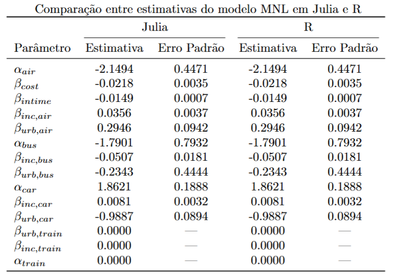